# Analytical Visualization on the History of Himalyan Expeditions

INFO 526 Final Project Proposal

This study analyzes Himalayan expeditions conducted from 2020 to 2024. It aims to understand the preferred routes of a particular nation and to determine how death rates for different agencies vary by time of year.

Author

Affiliation

Cat-Amit

School of Information, University of Arizona

```r
## install.packages("tidytuesdayR")
library(tidyverse)
library(janitor)
```

## Dataset

```r
tuesdata <- tidytuesdayR::tt_load('2025-01-21')

#Although our two questions only use exped_tidy, we have added code to make a separate peaks_tidy in case we find out that we need variables from that dataframe later on.

exped_tidy <- tuesdata$exped_tidy
peaks_tidy <- tuesdata$peaks_tidy

exped_tidy <- clean_names(exped_tidy)
peaks_tidy <- clean_names(peaks_tidy)

head(exped_tidy, n=10)
```

```
# A tibble: 10 × 69
   expid     peakid  year season season_factor  host host_factor route1   route2
   <chr>     <chr>  <dbl>  <dbl> <chr>         <dbl> <chr>       <chr>    <chr>
 1 EVER20101 EVER    2020      1 Spring            2 China       N Col-N… <NA>
 2 EVER20102 EVER    2020      1 Spring            2 China       N Col-N… <NA>
 3 EVER20103 EVER    2020      1 Spring            2 China       N Col-N… <NA>
 4 AMAD20301 AMAD    2020      3 Autumn            1 Nepal       SW Ridge <NA>
 5 AMAD20302 AMAD    2020      3 Autumn            1 Nepal       SW Ridge <NA>
 6 AMAD20303 AMAD    2020      3 Autumn            1 Nepal       SW Ridge <NA>
 7 AMAD20304 AMAD    2020      3 Autumn            1 Nepal       SW Ridge <NA>
 8 AMAD20305 AMAD    2020      3 Autumn            1 Nepal       SW Ridge <NA>
 9 AMAD20306 AMAD    2020      3 Autumn            1 Nepal       SW Ridge <NA>
10 AMAD20307 AMAD    2020      3 Autumn            1 Nepal       SW Ridge <NA>
# ℹ 60 more variables: route3 <lgl>, route4 <lgl>, nation <chr>, leaders <chr>,
#   sponsor <chr>, success1 <lgl>, success2 <lgl>, success3 <lgl>,
#   success4 <lgl>, ascent1 <chr>, ascent2 <chr>, ascent3 <lgl>, ascent4 <lgl>,
#   claimed <lgl>, disputed <lgl>, countries <chr>, approach <chr>,
#   bcdate <date>, smtdate <date>, smttime <chr>, smtdays <dbl>, totdays <dbl>,
#   termdate <date>, termreason <dbl>, termreason_factor <chr>, termnote <chr>,
#   highpoint <dbl>, traverse <lgl>, ski <lgl>, parapente <lgl>, camps <dbl>, …
```

```r
head(peaks_tidy, n=10)
```

```
# A tibble: 10 × 29
   peakid pkname      pkname2 location heightm heightf himal himal_factor region
   <chr>  <chr>       <chr>   <chr>      <dbl>   <dbl> <dbl> <chr>         <dbl>
 1 AMAD   Ama Dablam  Amai D… Khumbu …    6814   22356    12 Khumbu            2
 2 AMPG   Amphu Gyab… Amphu … Khumbu …    5630   18471    12 Khumbu            2
 3 ANN1   Annapurna I <NA>    Annapur…    8091   26545     1 Annapurna         5
 4 ANN2   Annapurna … <NA>    Annapur…    7937   26040     1 Annapurna         5
 5 ANN3   Annapurna … <NA>    Annapur…    7555   24787     1 Annapurna         5
 6 ANN4   Annapurna … <NA>    Annapur…    7525   24688     1 Annapurna         5
 7 ANNE   Annapurna … <NA>    Annapur…    8026   26332     1 Annapurna         5
 8 ANNM   Annapurna … <NA>    Annapur…    8051   26414     1 Annapurna         5
 9 ANNS   Annapurna … Annapu… Annapur…    7219   23684     1 Annapurna         5
10 APIM   Api Main    <NA>    Api Him…    7132   23399     2 Api/Byas Ri…      7
# ℹ 20 more variables: region_factor <chr>, open <lgl>, unlisted <lgl>,
#   trekking <lgl>, trekyear <dbl>, restrict <chr>, phost <dbl>,
#   phost_factor <chr>, pstatus <dbl>, pstatus_factor <chr>, peakmemo <dbl>,
#   pyear <dbl>, pseason <dbl>, pexpid <chr>, psmtdate <chr>, pcountry <chr>,
#   psummiters <chr>, psmtnote <chr>, refermemo <dbl>, photomemo <dbl>
```

```r
#write.csv(exped_tidy, "data/exped_tidy.csv")
#write.csv(peaks_tidy, "data/peaks_tidy.csv")
```

We chose this dataset because not only did our team find the prospect of analyzing Himalayan mountaineering expeditions to be incredibly interesting, but also because the dataset contained a good balance between qualitative and quantitative data, with a variety of different data types (character, integer, date, logical, etc.). The large amount of time data inspired us to think about potential time series visualizations and the variables present allowed for diverse questions from analysis of lethality to the impact of hiker background.

## Questions

Q1: Are certain routes favored by expeditions from particular nations, and do they have disparate success rates?

Q2: Do certain Agencies have a higher number of member/personal deaths than others with respect to season/date?

## Analysis plan

Data cleanup: after using clean_names(), we anticipate that data cleanup will only require ignoring NA values in the dataset.

#### Q1 Plan:

We’ll first count, for each country, how many times each route was attempted and how many of those attempts succeeded. Then we’ll make a bar chart where:

- **X-axis** is the route name (categorical)
- **Y-axis** is the number of attempts (numeric)
- **Bar fill** shows the success rate (e.g. darker = higher percentage of summits)

This layout lets us instantly see which routes each country prefers (tallest bars) and how well they do on them (color intensity). We can then tweak—say, switch to a heatmap of nation vs. route with attempts as tile size and success rate as color—if we want another perspective.

The variables involved in this graph are as follows:

Existing variables:

*nation* (Categorical) - Principle nationality.  
*route1,…,route4* (Categorical) - Climbing route.  
*success1,….,success4* (Binary/Numeric) - Success on route.

New variables to be created:

*route* (categorical) - A single “long” route identifier created by pivoting *route1–route4* into one column.  
*success* (binary/numeric) - Corresponding to each *route*, the matching *success* flag (0 = fail, 1 = success).  
*attempts* (numeric) - Count of expeditions per (*nation, route*) pair.  
success*_rate* (numeric, 0-1) - For each (*nation, route*):

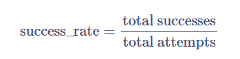

The approach to utilize the pivoted columns will be represent the routes bifurcation by individual peaks and then it will be plotted with correspondence to the success rate and number of attempts.

#### Q2 Plan:

We anticipate that the best way to answer this question is to have a graph with percent total death by agency. These graphs will be faceted by season. To account for the difference in number of traveling done by season, we plan to adverage the percent death values. So far, a bar graph is the anticipated result though we are open to trying different types of graphs. If a bar graph is the final graph, we will use a stacked bar chart that shows what portion of the total death by agency is hiker or member deaths.

The variables involved in this graph are as follows:

Existing variables:  
*agency* - Trekking agency  
*mdeaths* - Member deaths (per trip)  
*totmembers* - total members (per trip)  
*hdeaths* - hired personnel deaths (per trip)  
*tothired* - total hired personnel (per trip)  
*year* - year  
*season_factor* - season

New variables to be created:  
pmdeaths - *mdeaths*/*totmembers* - percent member deaths  
phdeaths -*hdeaths*/*tothired* -percent personnel deaths  
ptotdeaths - (*hdeaths*+ *mdeaths*)/(*tothired* + *totmembers* ) - percent total deaths

For each season, we will annotate temperature and weather conditions which will be researched from internet sources. This may require a second graph that colors based on route. If this is the case, we will also require the variable: *route1,…,route4*

## Plan of Attack

[output not shown]